# UFCFFY-15-M

# Cyber Security Analytics

## 08: Case Study - Text Analysis and Misinformation

#### Prof. Phil Legg

[figure not shown]

# 08: Text Analytics and Fake News

In this session we will cover:

- Scraping text, count occurrences and TF-IDF
- Case study on Fake News
- Advanced text analytics concepts

# Scraping text, and counting Occurrences

```python
import requests
import pandas as pd
import matplotlib.pyplot as plt
from bs4 import BeautifulSoup

page = requests.get('https://en.wikipedia.org/wiki/Computer_security')
soup = BeautifulSoup(page.content, 'html.parser')
text = soup.text.replace('\n', ' ').split(" ")
```

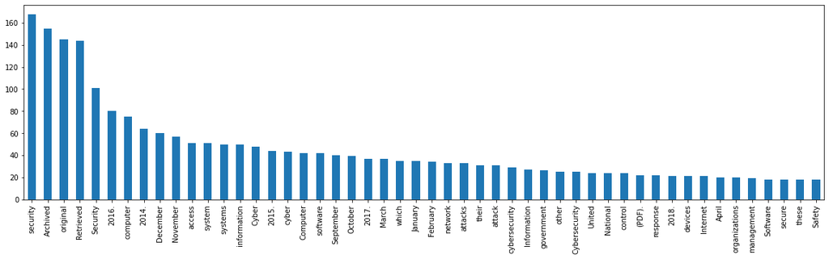

```python
# Word-level Occurrences
out = [w for w in text if len (w) > 4]
plt.figure(figsize=(20,5))
pd.value_counts(out).head(50).plot(kind='bar')
plt.show()
```

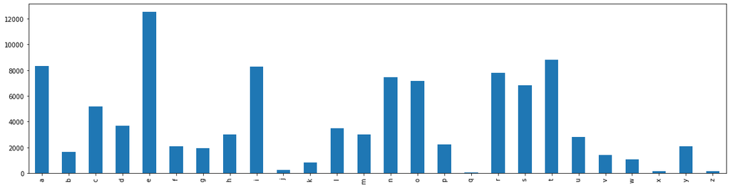

```python
# Characeter-level Occurrences
s = soup.text.lower().replace('\n', ' ')
out = [c for c in s if c in 'abcdefghijklmnopqrstuvwxyz']
plt.figure(figsize=(20,5))
pd.value_counts(out).sort_index().plot(kind='bar')
plt.show()
```

## Term Frequency – Inverse Document Frequency

[TF-IDF](https://en.wikipedia.org/wiki/Tf%E2%80%93idf) - accounts for occurrence of a term, whilst weighting against the occurrence in the whole document set. TF-IDF is calculated as TF * IDF, where:

- TF(t) = number of times t appears in a document / total number of terms in document
- IDF(t) = log (total number of documents / number of documents with t in)

**Example: “Heartbleed” and “Cyber”**

- Suppose “Heartbleed” occurs 10 times within a 100 word document: TF(Heartbleed) = 10/100 = 0.1. Suppose we have 1000 documents and “Heartbleed” occurs in 10 of these: IDF(Heartbleed) = log(1000 / 10) = 2. Then, TF-IDF = TF *IDF = 0.1* 2 = 0.2.
- Suppose now we look at the word “Cyber”, and assume it occurs 30 times within the 100 word document: TF(Cyber) = 30/100 = 0.3, but it also occurs in 750 of the 1000 documents: IDF(Heartbleed) = log(1000 / 750) = 0.124. Then, TF-IDF = TF *IDF = 0.3* 0.124 = 0.0372.

Here, Heartbleed is scored higher than Cyber because in relation to the overall document set it is deemed of greater significance.

# Case study example - Fake News

[Text Analytics Lab](https://pa-legg.github.io/csa)

# Advanced Concepts

- [Recurrent Neural Networks](https://en.wikipedia.org/wiki/Recurrent_neural_network) (known as RNN).
  - Deep learning for sequential/temporal data - *'The cat sat on the ...'*.
  - [Long Short-Term Memory](https://en.wikipedia.org/wiki/Long_short-term_memory) (LSTM) networks are the most popular form of RNN - resolves the 'vanishing gradient' problem.
- One-hot encoding works well for smaller dictionaries - how do we deal with larger sets?
  - [Word2Vec](https://en.wikipedia.org/wiki/Word2vec) provides a compact `embedding', like an autoencoder.
  - Two approaches:
    - 'continuous bag of words' - given a set of words, what word fits with the set?
    - 'skip-grams' - given a single word, what set of words would fit with this?
  - [Doc2Vec](https://medium.com/wisio/a-gentle-introduction-to-doc2vec-db3e8c0cce5e) - similar concept but for a set of documents rather than a set of words.
- Are we learning a single output (vector) or a set of output (sequence)? Models can be thought of as: vec2vec, vec2seq, seq2vec, and [seq2seq](https://en.wikipedia.org/wiki/Seq2seq).
  - [Language translation](https://keras.io/examples/nlp/lstm_seq2seq/) is a good candidate for seq2seq, since the input and output may both be of variable length.
- [Generative Pre-trained Transformer 3](https://en.wikipedia.org/wiki/GPT-3) (GPT-3) was released in 2020 by OpenAI in their research paper [“Language Models are Few-Shot Learners”](https://arxiv.org/abs/2005.14165).
  - It uses 175 billion parameters in their learning model, but achieves near-human accuracy. Whilst it can do traditional text tasks like sentence completion, they demonstrate it’s effectiveness for truly understanding text, such as executing commands as described by a human – from building applications based on a written description, smart assistants that can recognise tasks and provide recommendation, and many other examples that are available online.
- Two videos that explain this further: [2 minute papers](https://www.youtube.com/watch?v=_x9AwxfjxvE) and [Half Ideas](https://www.youtube.com/watch?v=8psgEDhT1MM).
- Research that led to the release of [ChatGPT](https://chat.openai.com/auth/login)

# Further reading

- [Ahmed, H, Traore, I, Saad, S. Detecting opinion spams and fake news using text classification, Security and Privacy, 2018; 1:e9. https://doi.org/10.1001/spy2.9](https://onlinelibrary.wiley.com/doi/full/10.1002/spy2.9)
- [Security Data Analytics and Visualisation - Text Analytics](http://www.cems.uwe.ac.uk/~pa-legg/sdav/07-textanalytics.html) - *more on Recommender Systems and Bayes Theorem*